# Part I - Ford Gobike Trip Data

## Multivariate Exploration

> Create plots of three or more variables to investigate your data even further. Make sure that your investigations are justified, and follow from your work in the previous sections.

`1.` The relation between Trip duration and user age, by different genders:

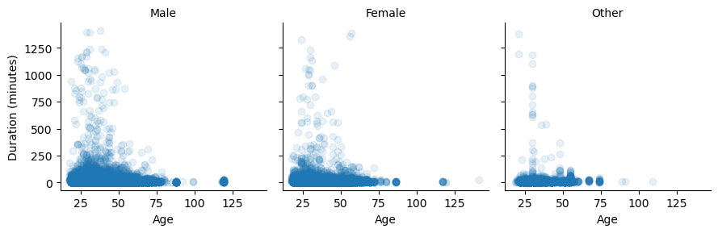

```python
bikedata_explore['member_gender'] = pd.Categorical(bikedata_explore['member_gender'], ['Male', 'Female', 'Other'])
g = sb.FacetGrid(data=bikedata_explore, col='member_gender', margin_titles=True)
g.map(plt.scatter, 'member_age','Duration_minutes',alpha=1/10);
g.set_titles(col_template="{col_name}")
g.set_xlabels(label="Age");
g.set_ylabels(label="Duration (minutes)");
```

```python
def hist2dgrid(x, y, **kwargs):
    """ Quick hack for creating heat maps with seaborn's PairGrid. """
    palette = kwargs.pop('color')
    bins_x = np.arange(0, 100, 5)
    bins_y = np.arange(0, 1000, 50)
    plt.hist2d(x, y, bins = [bins_x, bins_y], cmap = palette, cmin = 0.5)
```

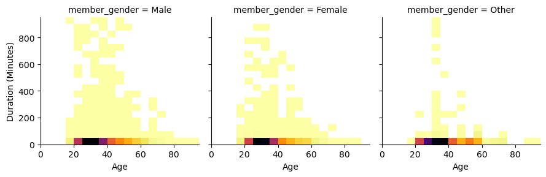

```python
# create faceted heat maps on levels of the cut variable
g = sb.FacetGrid(data = bikedata_explore, col = 'member_gender', col_wrap = 3, height = 3)
g.map(hist2dgrid, 'member_age', 'Duration_minutes',color='inferno_r')
g.set_xlabels('Age')
g.set_ylabels('Duration (Minutes)')

plt.show()
```

> The Gender has no effect on the relationship between the Age and the Duration.

`2.` The relation between Trip duration and user age in each city:

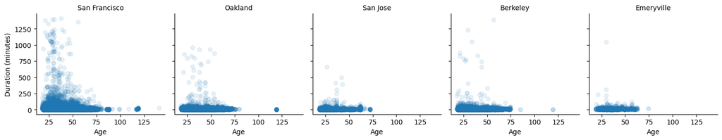

```python
sub_df=bikedata_explore[bikedata_explore['member_age'].notna()]
g = sb.FacetGrid(data=sub_df, col='city', margin_titles=True)
g.map(plt.scatter, 'member_age','Duration_minutes',alpha=1/10);
g.set_titles(col_template="{col_name}")
g.set_xlabels(label="Age");
g.set_ylabels(label="Duration (minutes)");
```

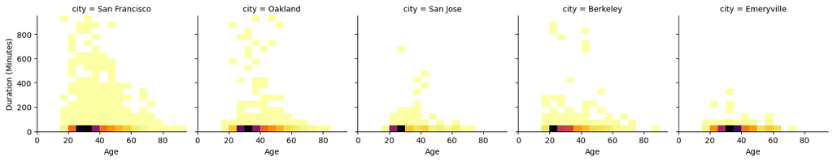

```python
# create faceted heat maps on levels of the cut variable
g = sb.FacetGrid(data = sub_df, col = 'city', height = 3)
g.map(hist2dgrid, 'member_age', 'Duration_minutes',color='inferno_r')
g.set_xlabels('Age')
g.set_ylabels('Duration (Minutes)')

plt.show()
```

The plot shows no effect of city to the relation between the Age and the Duration.

`3.` Average trip duration of each gender in each city:

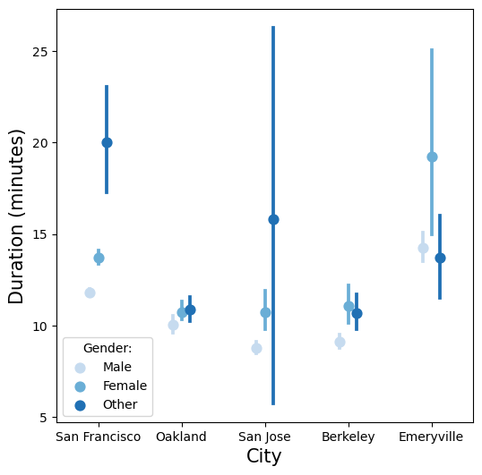

```python
fig = plt.figure(figsize = [6,6])
ax = sb.pointplot(data = bikedata_explore, x = 'city', y = 'Duration_minutes', hue = 'member_gender',
           palette = 'Blues', linestyles = '', dodge = 0.2)
plt.title('')
plt.ylabel('Duration (minutes)',size=15)
plt.xlabel('City',size = 15)
plt.legend(title='Gender:')
plt.show();
```

`4.` Duration of each gender, by user types

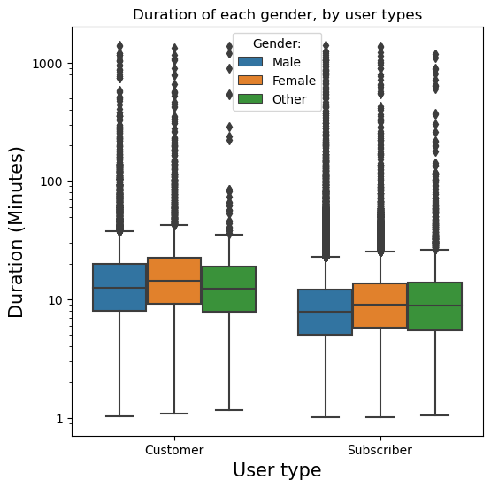

```python
fig = plt.figure(figsize = [6,6])
sb.boxplot(data = bikedata_explore, x = 'user_type', y = 'Duration_minutes', hue = 'member_gender')
# ax = sb.pointplot(data = bikedata_explore, x = 'user_type', y = 'Duration_minutes', hue = 'member_gender',
        #    palette = 'Blues', linestyles = '', dodge = 0.2)
plt.yscale('log')
plt.title('Duration of each gender, by user types')
y_ticklocs=[1,10,100,1000]
y_ticklabels=['1','10','100','1000']
plt.yticks(y_ticklocs,y_ticklabels)
plt.ylabel('Duration (Minutes)',size=15)
plt.xlabel('User type',size = 15)
plt.legend(title='Gender:')
plt.show();
```

> It is observed that non-subscribers have longer trips than subscriber. And regardless of subscription status, female tend to have the longest trips duration in comparison with other genders.

`5.` Average customer with different gender, by different trips range:

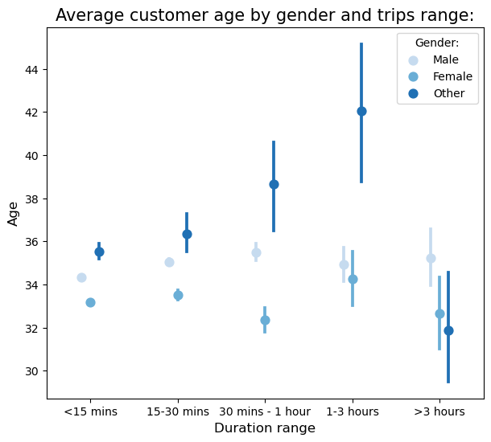

```python
fig = plt.figure(figsize = [7,6])
ax = sb.pointplot(data = bikedata_explore, x = 'Duration_Range', y = 'member_age', hue = 'member_gender',
           palette = 'Blues', linestyles = '', dodge = 0.2)
plt.title('Average customer age by gender and trips range:',size=15)
plt.ylabel('Age',size=12)
plt.xlabel('Duration range',size = 12)
plt.legend(title='Gender:')
plt.show();
```

> The average age of male and female users in all different duration ranges were from 32 to 36. While the average age of 'other' genders fluctuated with different duration trip ranges.

`6.` Average duration of each gender, in different city

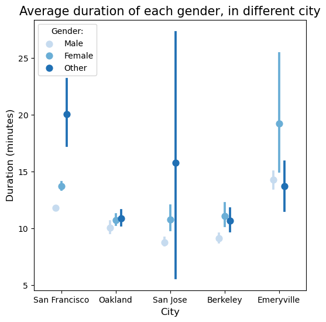

```python
fig = plt.figure(figsize = [6,6])
ax = sb.pointplot(data = bikedata_explore, x = 'city', y = 'Duration_minutes', hue = 'member_gender',
           palette = 'Blues', linestyles = '', dodge = 0.2)
plt.title('Average duration of each gender, in different city',size=15)
plt.ylabel('Duration (minutes)',size=12)
plt.xlabel('City',size = 12)
plt.legend(title='Gender:')
plt.show();
```

> The average duration of male and female in San Francisco, Oakland, San Jose and Berkeley were less than 15 minutes. Whereas female and male in Emerville seems to had longer trips, which should be consider that the number of trips recorded in Emereville is remarkably less than those in other cities.

`7.` Average trips duration each day of Feb-2019 by gender

[figure not shown]

```python
fig = plt.figure(figsize = [10,8])
ax = sb.pointplot(x=bikedata_explore['start_time'].dt.day,
                  y = bikedata_explore['Duration_minutes'],
                  hue = bikedata_explore['member_gender'],
                  errorbar=None,
                  dodge = 0.2,  scale = 0.7)
plt.title('Daily average trips duration of Feb-2019 by gender',size=15)
plt.ylabel('Duration(minutes)',size=12)
plt.xlabel('Day of 2019 Feb',size = 12)
plt.legend(title='Gender:')
plt.show()
```

> As shown in above plots, female' average duration was higher than male counterparts. Male and female daily average trips duration seems to had the similar trends.

`8.` Average trips duration each day of Feb-2019 by subscription status

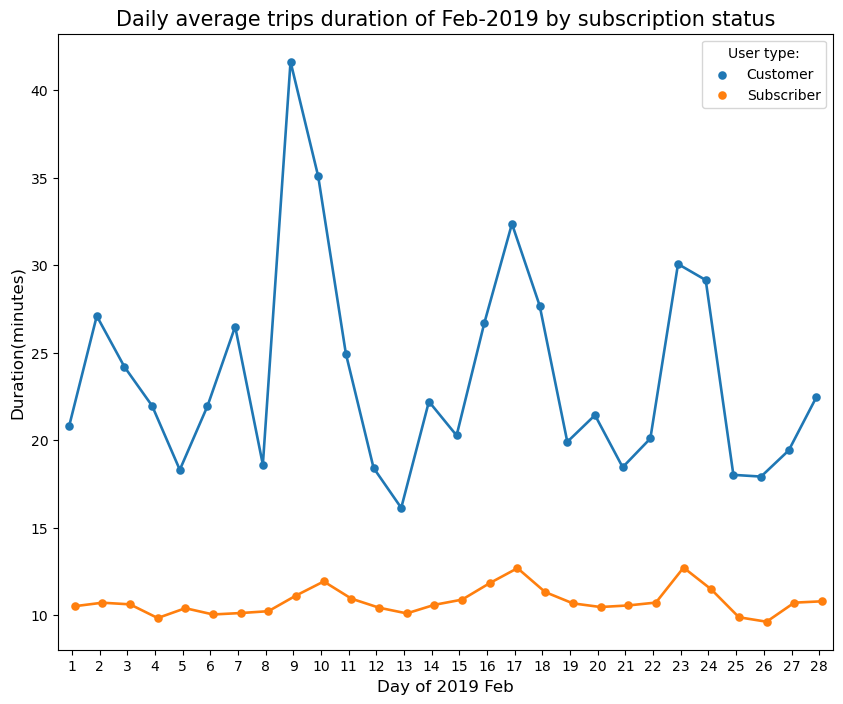

```python
fig = plt.figure(figsize = [10,8])
ax = sb.pointplot(x=bikedata_explore['start_time'].dt.day,
                  y = bikedata_explore['Duration_minutes'],
                  hue = bikedata_explore['user_type'],
                  errorbar=None,
                  dodge = 0.2,  scale = 0.7)
plt.title('Daily average trips duration of Feb-2019 by subscription status',size=15)
plt.ylabel('Duration(minutes)',size=12)
plt.xlabel('Day of 2019 Feb',size = 12)
plt.legend(title='User type:')
plt.show()
```

> Subscribers tends to have stable duration usage than non-subscribers

### Talk about some of the relationships you observed in this part of the investigation. Were there features that strengthened each other in terms of looking at your feature(s) of interest?

> - Subscribers tends to have stable duration usage than non-subscribers
> - Male and female daily average trips duration seems to had the similar trends.

### Were there any interesting or surprising interactions between features?

> Though Female average duration were higher than male counterpart. Male and female daily average trips duration seems to had the similar trends.

## Conclusions

> Key insights:
> 1. Distribution of trips durations: Trip durations in the dataset take on a very large range of values, from about only 1 minute at the lowest, to about 1424 minutes (23 hours and 43 minutes) at the highest. The average duration time is 12.1 minutes. Plotted on a logarithmic scale, the distribution of trip durations takes on a unimodal shape.
> 2. User-status: 89.17% of the service are used by Subscribers, as 8 times as much as that of non-subscribers (Customers), with 10.83%
> 3. Number of trips by duration ranges: Most of the trips are less than 15 minutes. While the figure for the trips within 15-30 minutes was 28,564. Trips takes more than 1 hours only hold small percentage of the total figure.
> 4. Number of trips in each city: The number of trips in San Francisco was the highest with 133708 trips in Feb 2019. Trips counted in Oakland was 20434 slightly higher than Berkeley counterpart, acounted for 19449 trips. The number of trips in San Jose and Emeryville were 8270 and 1551, respectively.
> 5. User types vs. trip durations: Users who did't subribe had longer trips than subscribers.
> 6. Genders vs. trip durations: Males have shorter trips than other genders.
> 7. Bike sharing options vs. trip durations: Trips with bike sharing option were shorter than those were without this option.
> 8. Average trips duration each day of Feb-2019 by gender: Female average duration was higher than male counterpart. Male and female daily average trip durations seem to had the similar trends.
> 9. Average trips duration each day of Feb-2019 by subscription status: Subscribers tends to have stable duration usage than non-subscriber